# Representativitet for 2023 data

Fyrtårnprosjektet

Nye tilfeller av personskader innen aktivitetsdata for somatikk velges ut på denne måten:

- Hoveddiagnosekode i ICD10 kapittel XIX, kodene S00-T78.
- Komplikasjoner og følgetilstander er ikke tatt med.
- Start av behandling for skadetilfellet i 2023.
- Planlagt (elektiv) behandling er holdt utenfor.

Et skadetilfelle kan generere flere kontakter med helsevesenet. For å unngå å telle hvert skadetilfelle flere ganger, skal samme skade ikke være mindre enn **3 dager** fra forrige registreringsdato (`innDato`) og at kontakten må være registrert med akutt hastegrad. Dersom pasienten er registrert med flere slike opphold for samme skade på mer enn 3 dager fra forrige registreringsdato, kan samme skade bli telt flere ganger. Det er **327 057** skadetilfeller ble registeret i 2023 i hele landet hvor **166 318** skadetilfeller er rapportert fra Fyrtårnenhetene. Analysen som er gjort her er basert på [rapporten](https://www.tryggtrafikk.no/content/uploads/2024/03/Fyrtarnsprosjektet2021_nett_enkeltsider.pdf) (vedlegg 5) fra Trygg Trafikk.

## Kjønn

Kjønnsfordelingen i prosent av behandlede skadepasienter ved Fyrtårnenhetene sammenliknet med alle sykehusene og legevaktene (inkludert Fyrtårnenhetene).

Tabell 1: Fyrtårnsykehusene og legevakter

| kjonn | N | prosent | beskrivelse |
| --- | --- | --- | --- |
| 1 | 88782 | 53.4 | Mann |
| 2 | 77536 | 46.6 | Kvinne |
| Total | 166318 | 100.0 |  |

Tabell 2: Alle sykehusene og legevakter

| kjonn | N | prosent | beskrivelse |
| --- | --- | --- | --- |
| 1 | 172345 | 52.7 | Mann |
| 2 | 154712 | 47.3 | Kvinne |
| Total | 327057 | 100.0 |  |

Kjønnsfordelingen er nokså like mellom Fyrtårnenhetene og alle sykehusene og legevaktene (inkludert Fyrtårnenhetene). Dette vises tydeligere i Figur 1.

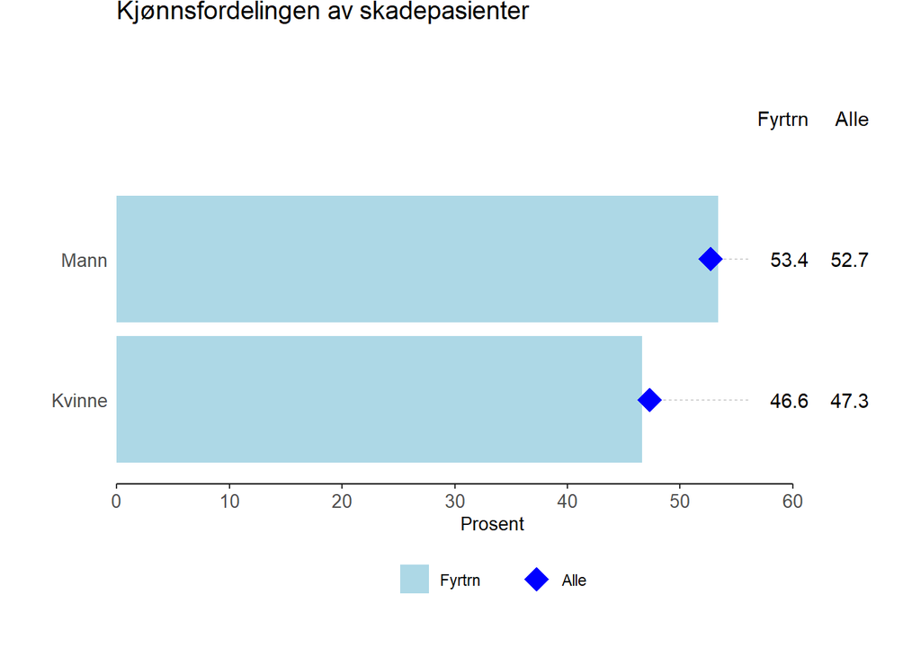

Figur 1: Kjønnsfordelingen av skadepasienter

## Alder

Aldersfordelingen i prosent av behandlede skadepasienter ved Fyrtårnenhetene sammenlignet med alle sykehusene og legevaktene (inkludert Fyrtårnenhetene).

Tabell 3: Fyrtårnsykehusene og legevakter

| agegp | N | prosent |
| --- | --- | --- |
| 0-14 | 35757 | 21.5 |
| 15-24 | 27238 | 16.4 |
| 25-44 | 40949 | 24.6 |
| 45-64 | 30472 | 18.3 |
| 65-79 | 18656 | 11.2 |
| 80+ | 13246 | 8.0 |
| Total | 166318 | 100.0 |

Tabell 4: Alle sykehusene og legevakter

| agegp | N | prosent |
| --- | --- | --- |
| 0-14 | 66173 | 20.2 |
| 15-24 | 50732 | 15.5 |
| 25-44 | 71368 | 21.8 |
| 45-64 | 63552 | 19.4 |
| 65-79 | 43113 | 13.2 |
| 80+ | 32119 | 9.8 |
| Total | 327057 | 100.0 |

Andelen skadde personer under 45 år er høyere i Fyrtårnenhetene sammenlignet med alle enhetene samlet, mens andelen av skadde personer over 44 år er høyere i alle enhetene sammenlignet med Fyrtårnenhetene. Dette fremgår tydelig av Figur 2 nedenfor.

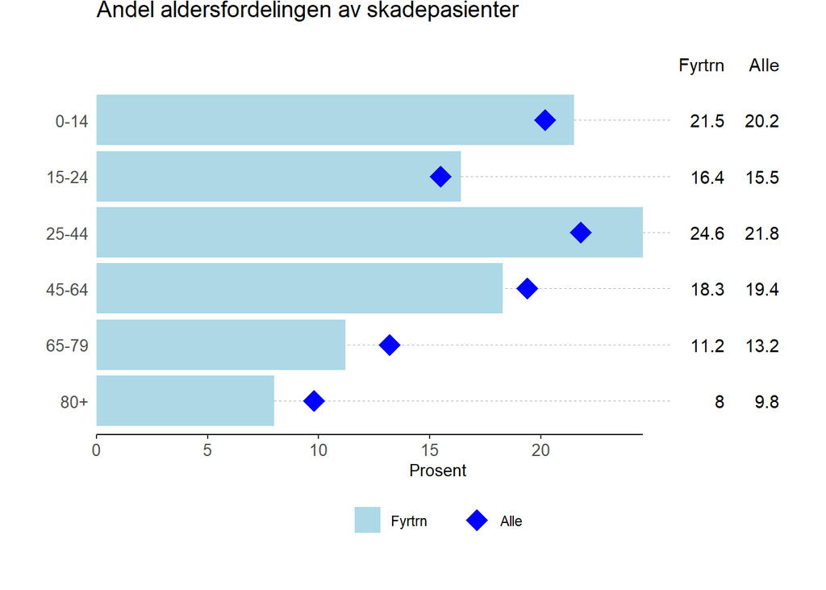

Figur 2: Andel aldersfordelingen av skadepasienter

## Diagnoser

Diagnosefordelingen i prosent av behandlede skadepasienter ved Fyrtårnenhetene sammenlignet med alle sykehusene og legevaktene (inkludert Fyrtårnenhetene).

Tabell 5: Alle sykehusene og legevakter

| icd | N | prosent | beskrivelse |
| --- | --- | --- | --- |
| 0 | 47772 | 14.61 | Hode |
| 1 | 2459 | 0.75 | Hals |
| 2 | 9026 | 2.76 | Toraks |
| 3 | 9760 | 2.98 | Buk, nedre rygg |
| 4 | 26938 | 8.24 | Skulder, overarm |
| 5 | 35898 | 10.98 | Albu, underarm |
| 6 | 66100 | 20.21 | Håndledd, hånd |
| 7 | 18745 | 5.73 | Hofte, lår |
| 8 | 40983 | 12.53 | Kne, legg |
| 9 | 51557 | 15.76 | Ankel, fot |
| 10 | 551 | 0.17 | Multiple |
| 11 | 2055 | 0.63 | Uspesifisert |
| 12 | 5234 | 1.60 | Fremmedlegeme |
| 13 | 4053 | 1.24 | Brannskader |
| 14 | 111 | 0.03 | Forstskade |
| 15 | 590 | 0.18 | Forgiftning |
| 16 | 1543 | 0.47 | Toksiske virkninger |
| 17 | 3682 | 1.13 | Annet |
| Total | 327057 | 100.00 |  |

Tabell 6: Fyrtårnsykehusene og legevakter

| icd | N | prosent | beskrivelse |
| --- | --- | --- | --- |
| 0 | 28878 | 17.36 | Hode |
| 1 | 1265 | 0.76 | Hals |
| 2 | 4783 | 2.88 | Toraks |
| 3 | 4682 | 2.82 | Buk, nedre rygg |
| 4 | 11901 | 7.16 | Skulder, overarm |
| 5 | 16448 | 9.89 | Albu, underarm |
| 6 | 34916 | 20.99 | Håndledd, hånd |
| 7 | 7368 | 4.43 | Hofte, lår |
| 8 | 20004 | 12.03 | Kne, legg |
| 9 | 27381 | 16.46 | Ankel, fot |
| 10 | 237 | 0.14 | Multiple |
| 11 | 1170 | 0.70 | Uspesifisert |
| 12 | 2156 | 1.30 | Fremmedlegeme |
| 13 | 2531 | 1.52 | Brannskader |
| 14 | 62 | 0.04 | Forstskade |
| 15 | 299 | 0.18 | Forgiftning |
| 16 | 707 | 0.43 | Toksiske virkninger |
| 17 | 1530 | 0.92 | Annet |
| Total | 166318 | 100.00 |  |

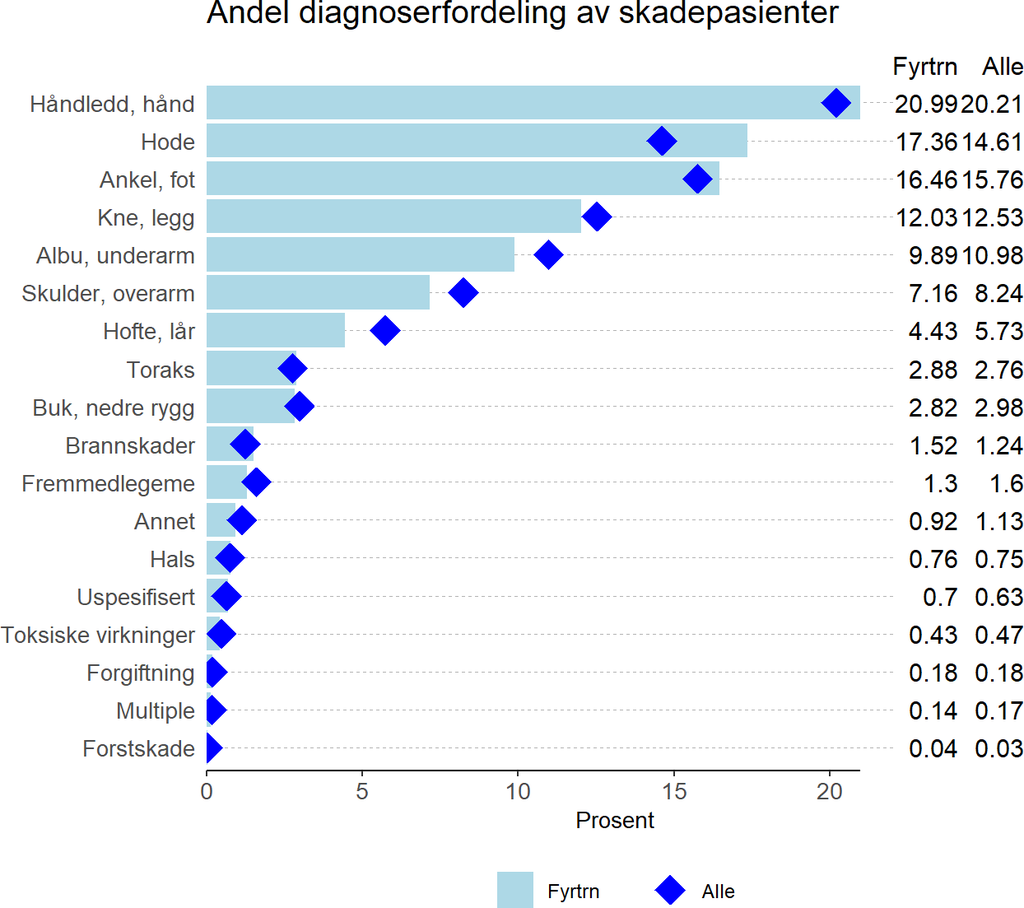

Figur 3: Andel diagnoserfordeling av skadepasienter